# Final Project

## **Welcome** to my final project page!

**Caleb Sawyer**  
BIOL-3100  
*Introduction to Data Analysis*

This project functions as a walkthrough for performing a bacterial phylogeny with amino acid data as a reference using **RStudio**. This is an alternative to using the MEGA 11 software we tinkered around with in Dr. Ogden’s Molecular Evolution and Bioinformatics class. This reflects my path through the project, but there are many other alignment, model testing, phylogenetic tree, and tree viewer tools out there, that all work similarly. There are also important phylogenetic parameters that are not discussed here, but can change depending on your data set, taxa and evolutionary context.

This data set consists of Cytochrome C oxidase subunit 1 (Cox1) amino acid sequences pulled from genbank based on the genus of bacterial samples taken from seagrass (*Syringodium isoetifolium*) around **Wallace’s Line**.

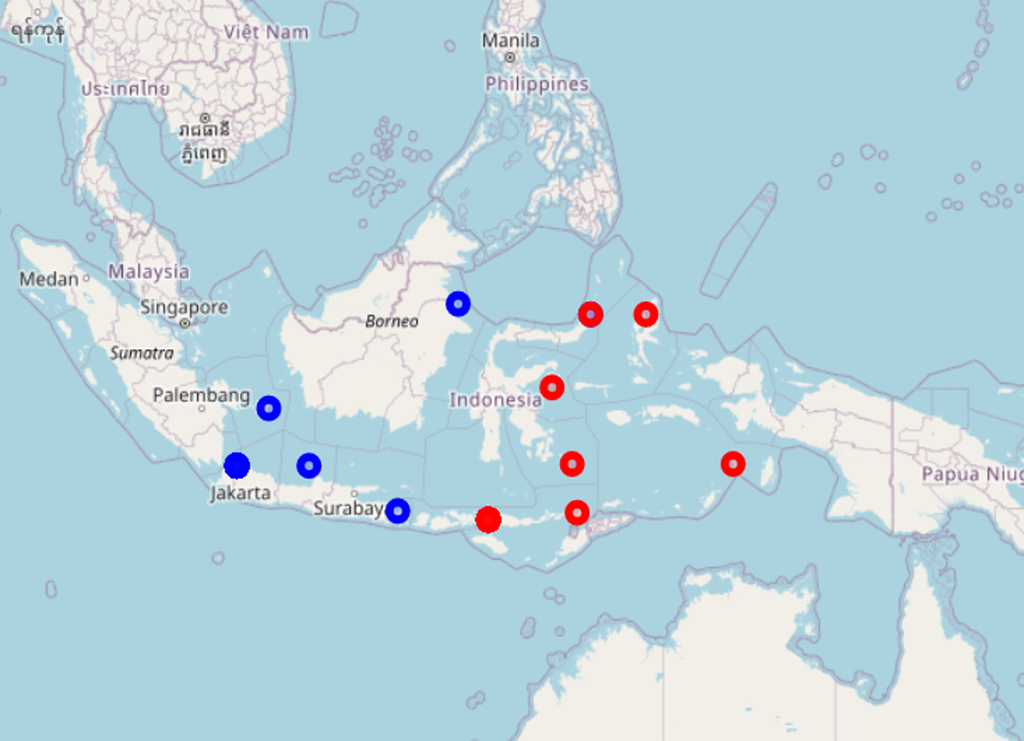

Those significant genera are the following:

```
##  [1] "Mucilaginibacter" "Rhizobium"        "Sphingomonas"     "Acinetobacter"
##  [5] "Elizabethkingia"  "Bradyrhizobium"   "Aureitalea"       "Rhodospirillum"
##  [9] "Arcobacter"       "Marixanthomonas"  "Pelagicoccus"     "Azonexus"
## [13] "Thiogranum"       "Bizionia"         "Paracoccus"       "Vibrionimonas"
## [17] "Wandonia"         "Bauldia"          "Litorimonas"      "Anderseniella"
```

Since the project requires a minimum of 30 taxa, at least 10 more from the 254 samples need to be chosen.

Using a random number generator from a randomly generated seed, we determined the other 10 samples from a list of all the taxa.

```
seed <- round(runif(1, 1, 2147483647))
```

```
seed

[1] 141372682

set.seed(141372682)

#random selection of other 10 taxa
newtaxa <- round(runif(10, 1, 254))
```

## Step 0

### Load Packages:

R packages are collections of functions that help do work a lot easier. Each individual package helps with different things, and depending on which tools you use, these will change. I would suggest regardless of path starting with **tidyverse**. Full descriptions of each package can be found elsewhere.

```
library(tidyverse)
library(janitor)
library(bio3d)
library(BiocManager)
library(phangorn)
library(kableExtra)
library(ggtree)
```

For alignment, I used Multiple Sequence Alignment (MSA) from the package BiocManager.

```
# - file manipulation
BiocManager::install("msa")
```

*Note: Any code chunks that add or modify local files are marked with “# - file manipulation”. Any code chunks that involve long run times, like model testing, alignments, phylogenetic tree generation, etc. are marked with “# - long runtime” in the script. These shouldn’t be run more than once. Save a local object or file, and load that going forward to avoid redundancy.*

## Step 1

### Read in the data

Read in the csv file so you can work with it. Here, I’ve used the KableExtra package to make it an easily viewable table.

```r
df <-
  read_csv("./taxa_list_new_csv.csv") %>%
  clean_names()

df %>%
  kable() %>%
  row_spec(0,color="black") %>%
  kable_material_dark(lightable_options = 'hover') %>%
  scroll_box(width="900px", height= "350px")
```

| taxa | full_name | wg_genbank | cox1_genbank | gene | aa_seq |
| --- | --- | --- | --- | --- | --- |
| > Archaea (outgroup) | Halosimplex rubrum | CP058910.1 | QLH79945.1 | cbb3-type cytochrome c oxidase subunit I [Halosimplex rubrum] | MSSVKRWFVTTNHKDIGILYTITALFFLVLGGVLAMLMRVQLWSPGAGVLSAGAYNQAVS…… |
| > Acinetobacter (sig) | Acinetobacter baumannii | LT605059.1 | SCD14880.1 | cytochrome<a0>c<a0>assembly protein [Acinetobacter<a0>baumannii] | MISLPLVYTILALIAYTTSFWYLFIRLMSKREPNPWLFAFVTTLALLLHGTVLCHAMLTP…… |
| > Alteromonas (non-sig) | Alteromonas<a0>macleodii | CP003841.1 | AFS39352.1 | cytochrome<a0>c<a0>oxidase<a0>subunit<a0>I [Alteromonas macleodii ATCC 27126] | MSKATEVISPDTSAPHDGHLHDDHEHHDHIPKGITRWLFTTNHKDIGTLYLWFAFIMFLV…… |
| > Arcobacter (sig) | Arcobacter<a0>lacus | MUXF01000019.1 | PUE64869.1 | cytochrome C [Arcobacter lacus] | MNWKLPFDIPLITPTLGLPLEFFSILGIIVFVVHICFIYMLIGASTASVIYNIMGVFKKD…… |
| > Aureitalea (sig) | Aureitalea<a0>marina | MQUB00000000.1 | PQB05155.1 | cytochrome<a0>c<a0>oxidase<a0>subunit<a0>I [Aureitalea<a0>marina] | MSAHAPAAAIDHHDDHEHHHKETFVTKYIFSQDHKMISKQYLITGLIMGFIGIAMSLLFR…… |
| > Azonexus (sig) | Azonexus fungiphilus | RBXP01000018.1 | RKT50364.1 | cytochrome<a0>c<a0>oxidase<a0>cbb3-type<a0>subunit<a0>1<a0>[Azonexus fungiphilus] | MSGTQTTYNDKVVRQFTVMTVIWGIVGMLVGVIIAAQLVWPELNFGPWLHFGRLRPLHTN…… |
| > Bauldia (sig) | Bauldia<a0>litoralis | FMXQ00000000.1 | SDB28484.1 | cytochrome c oxidase<a0>subunit 1 [Bauldia<a0>litoralis] | MAYGAAAAGHEHHHPTGWRRWLYSTNHKDIGTLYLIFAIFSGIVGGALSIGIRLELMQPG…… |
| > Bizionia (sig) | Bizionia<a0>arctica | BMFQ01000002.1 | GGG49283.1 | cytochrome<a0>c<a0>oxidase<a0>subunit<a0>1<a0>[Bizionia<a0>arctica] | MSLYIDIPEDKEQLPSLKTGQGKLAWMASVDHKQLGIMYLWLALVFFVIGGLEAMMIRAQ…… |
| > Blastopirellula (non-sig) | Blastopirellula<a0>retiformator | SJPF01000001.1 | TWT38719.1 | cytochrome c oxidase subunit 1<a0>[Blastopirellula<a0>retiformator] | MAIAEAEQSSAPLPLVTQLHGWVTTVDHKRIGIMYILMSFLFLVVGGIEALLIRLQLWVP…… |
| > Bradyrhizobium (sig) | Bradyrhizobium<a0>vignae | RDQF01000010.1 | RXH04167.1 | cytochrome c oxidase subunit 1<a0>[Bradyrhizobium<a0>vignae] | MATSAAAHGDHAQAHGHDEHAHPTGWRRYVYSTNHKDIGTMYLIFAVIAGIIGAAMSIAI…… |
| > Elizabethkingia (sig) | Elizabethkingia<a0>anophelis | ANIW01000057.1 | ELR79882.1 | Cbb3-type<a0>cytochrome<a0>oxidase,<a0>subunit<a0>1<a0>[Elizabethkingia<a0>anophelis R26] | METQKFSYDNNIVRAFLYATIVFGIAGFILGLTAALMLFYPELPEFLFGTDDTTIQSLKS…… |
| > Erythrobacter (non-sig) | Erythrobacter<a0>litoralis | CP017057.1 | AOL24085.1 | cytochrome c oxidase subunit 1<a0>[Erythrobacter<a0>litoralis] | MATTAEGFDIHQEDHADHADHKPGFFSRWFMSTNHKDIGTLYLIFAIIAGVIGGAISGIM…… |
| > Flexithrix (non-sig) | Flexithrix<a0>dorotheae | NA | WP_020527382.1 | cytochrome-c<a0>oxidase, cbb3-type<a0>subunit<a0>I [Flexithrix<a0>dorotheae] | MKNPELSKLDVEFEQFSYDNATVRKFIIATTIFGIIGMLVGLTAAFQLVFPSLNFGLEYT…… |
| > Gilvibacter (non-sig) | Gilvibacter<a0>sp. | CP019333.1 | ARV11542.1 | cytochrome<a0>c<a0>oxidase<a0>subunit<a0>I [Gilvibacter<a0>sp. SZ-19] | MSAQGYAHPVEHDDHGHHHKETFITKYIFSQDHKMISKQYLITGLFMGIIGIAMSLIFRL…… |
| > Litorimonas (sig) | Litorimonas<a0>taeanensis | RBII01000002.1 | RKQ69272.1 | cytochrome<a0>c<a0>oxidase<a0>subunit<a0>1 [Litorimonas<a0>taeanensis] | MVAISDNDEGMYDDGKPGFFARWFYSTNHKDIGTLYLIFGIISGLIGGFLSFMMRMELAE…… |
| > Marixanthomonas (sig) | Marixanthomonas<a0>spongiae | QEHR01000001.1 | PVW17273.1 | cytochrome<a0>c<a0>oxidase<a0>subunit<a0>I [Marixanthomonas<a0>spongiae] | MSAHAQDVAVDHHDDHGHHHKETFITKYIFSQDHKMISKQYLITGIFMGIIGILMSVLFR…… |
| > Modicisalibacter (non-sig) | Modicisalibacter<a0>tunisiensis | NA | WP_263479044.1 | cbb3-type<a0>cytochrome c oxidase subunit I<a0>[Modicisalibacter<a0>tunisiensis] | MIEQPTLSHIVNGSIVTAAASLVVLGALATVVLITRFGKWRVLWSDWLTSVDHKRIGIMF…… |
| > Mucilaginibacter (sig) | Mucilaginibacter<a0>corticis | VLPK01000001.1 | TSJ44608.1 | cytochrome c oxidase subunit I<a0>[Mucilaginibacter<a0>corticis] | MIAKQFLITGITMAVIAMLLSILFRIQLAYPDKSFPLLETLLGRFAPEGRLDPEFYLSLV…… |
| > Paracoccus (sig) | Paracoccus<a0>sanguinis | JRKQ01000019.1 | KGJ22806.1 | cytochrome C oxidase subunit I<a0>[Paracoccus<a0>sanguinis] | MADAAVHGHGEHHDTRGFFTRWFMSTNHKDIGVLYLFTAGVVGLISVCFTVYMRMELQHP…… |
| > Pelagicoccus (sig) | Pelagicoccus<a0>albus | NA | WP_185658386.1 | cbb3-type<a0>cytochrome c oxidase subunit 1<a0>[Pelagicoccus<a0>albus] | MNLICNLFSSVFPTLEGDGSKRDREQGIDASMRFATLGLIKGSVFWLLVSSLLGLIVSVK…… |
| > Psychrosphaera (non-sig) | Psychrosphaera<a0>ytuae | CP072110.1 | QTH62927.1 | cytochrome c oxidase subunit 1 | MSSVDNTAVDHHDDHEHHGAPKGIMRWLLTTNHKDIGTLYLLFSLLMFFIGGAMAMVIRA…… |
| > Reinekea (non-sig) | Reinekea<a0>marinisedimentorum | SLZR01000007.1 | TCS41004.1 | cytochrome<a0>c<a0>oxidase<a0>subunit<a0>1 [Reinekea<a0>marinisedimentorum] | MTTLDHDHSDHGPAKGLSRWLFSTNHKDIGTLYLWFSLSMFFLGGLFAMVIRAELFQPGL…… |
| > Rhizobium (sig) | Rhizobium<a0>sp. | SLYE01000001.1 | TCQ12500.1 | cytochrome c oxidase subunit 1<a0>[Rhizobium<a0>sp. PP-F2F-G36] | MAGTTAHTDHLHDHSNGHDHSRDHAHDDHAHKPLTFFQRWFLSTNHKDIGTLYLIFAIFA…… |
| > Rhodospirillum (sig) | Rhodospirillum<a0>rubrum | CP003046.1 | AEO49876.1 | cbb3-type<a0>cytochrome<a0>c<a0>oxidase<a0>subunit<a0>I [Rhodospirillum<a0>rubrum F11] | MTQATIARGARADTEPYVEGVIKKFVIAAVLWGVVGFIAGDVIAWQLAFPSLNMDLEWTS…… |
| > Ruegeria (non-sig) | Ruegeria<a0>marisrubri | LQBQ01000001.1 | KUJ85684.1 | cytochrome C oxidase subunit I<a0>[Ruegeria<a0>marisrubri] | MADAAIHGHEHEDQRGFFTRWFMSTNHKDIGILYLVFSAIAGLISVLMTVYMRLELMHPG…… |
| > Sphingomonas (sig) | Sphingomonas<a0>deserti | PXYI01000010.1 | PSJ37028.1 | cytochrome c oxidase subunit I<a0>[Sphingomonas<a0>deserti] | MTDTTANATHFQTHEAHDAHHDADHKPGFFARWFMSTNHKDIGTLYLIFAIIAGIIGGTI…… |
| > Tenacibaculum (non-sig) | Tenacibaculum<a0>adriaticum | VNIA01000001.1 | TYQ00311.1 | cytochrome c oxidase subunit 1<a0>[Tenacibaculum<a0>adriaticum] | MSDHHHKETFVTKYMFSTDHKMISKQFLITGMFMGIIGVFMSMLFRLQIAWPEKSFSIIE…… |
| > Thiogranum (sig) | Thiogranum<a0>longum | SMFX01000001.1 | TCK17076.1 | cytochrome<a0>c<a0>oxidase<a0>subunit<a0>1 [Thiogranum<a0>longum] | MSTATAHDDHHGPASGLLRWVFTTNHKDIGTLYLLFSLLMFMVGGAMAMVIRAELFEPGL…… |
| > Tropicobacter (non-sig) | Pelagimonas phthalicica | SOAP01000002.1 | TDS91883.1 | cytochrome c oxidase subunit 1<a0>[Pelagimonas phthalicica] | MADAAIHGHEHEDNRGFFTRWFMSTNHKDIGILYLIVSALAGLVSVIFTVYMRMELMEPG…… |
| > Vibrio (non-sig) | Vibrio<a0>coralliirubri | CCJZ01000011.1 | CDS98759.1 | Cytochrome c oxidase subunit 1<a0>[Vibrio<a0>coralliirubri] | MSSPINKPVKSAPAEDQVLSHSVEGTLGNNDLPVDDHDSHAAPKGWARWLYSTNHKDIGT…… |
| > Vibrionimonas (sig) | Sediminibacterium magnilacihabitans | PVEQ01000004.1 | PQV61134.1 | cytochrome c oxidase subunit 1<a0>[Sediminibacterium magnilacihabitans] | MSNEAVVHAHPGLAHEVHGDHHEHHHHETFITKYVFSQDHKMIAKQFLITGMVWAVLGGL…… |

This csv is an excel spreadsheet my group fashioned while collecting sequences, taxa, genbank numbers, etc. It’s not tidied up into a form we can work with easily in R, so that needs to be done first.

## Step 2

### Tidy Up the Data

The “data” to work with here needs to be the sequences we are looking to align, and create a phylogeny from. In our case, the source of sequences is an excel spreadsheet with NCBI GenBank accession numbers listed in a column, and the sequence in another.

*What is “Tidy” data? Tidy format is a format that data sets should be in to make it easy to process. There’s a set of rules, but essentially it boils down to “one observation per row”. Most data people work with in R starts as a hot steamy pile of* **GaRbAgE** *that only makes sense to the idiot who filled out the spreadsheet, with no regard to its use-ability. Read more into it here: [R for Data Science 12: Tidy Data](https://r4ds.had.co.nz/tidy-data.html#tidy-data-1) [Journal of Statistical Software](https://github.com/gzahn/Data_Course/blob/master/Readings/tidy-data_Wickham.pdf)*

In this case, that idiot is **me**, and the “data” is a spreadsheet of GenBank accession numbers from NCBI, seen above. I’ve cleaned it up a bit to make it more usable.

*See code for details* –>

```r
#duplicate fasta format name column and manipulate one
df$taxa <-
  gsub("> ",">",df$taxa)

df$taxa_name_fasta=df$taxa

#The "\xa0" is a stand in for the ? square box "replacement" character
df$full_name <-
  gsub("\xa0"," ",df$full_name)

df$gene <-
  gsub("\xa0"," ",df$gene)

df$taxa <-
  gsub("[()]","",df$taxa)

df$taxa <-
  df$taxa %>%
  str_remove(">")

df <-
  separate(df,col=taxa,into = c("taxa_genus","sig_type"),sep=' ',convert=FALSE)

df$sig_type <- as.factor(df$sig_type)

df$aa_seq <-
  df$aa_seq %>% str_trunc(15,ellipsis="...")

df$gene <-
  df$gene %>% str_trunc(33,ellipsis="...")


df %>%
  kable() %>%
  row_spec(0,color="black") %>%
  kable_material_dark(lightable_options = 'hover') %>%
  scroll_box(width="900px", height= "350px")
```

| taxa_genus | sig_type | full_name | wg_genbank | cox1_genbank | gene | aa_seq | taxa_name_fasta |
| --- | --- | --- | --- | --- | --- | --- | --- |
| Archaea | outgroup | Halosimplex rubrum | CP058910.1 | QLH79945.1 | cbb3-type cytochrome c oxidase… | MSSVKRWFVTTN… | >Archaea (outgroup) |
| Acinetobacter | sig | Acinetobacter baumannii | LT605059.1 | SCD14880.1 | cytochrome c assembly protein … | MISLPLVYTILA… | >Acinetobacter (sig) |
| Alteromonas | non-sig | Alteromonas macleodii | CP003841.1 | AFS39352.1 | cytochrome c oxidase subunit I… | MSKATEVISPDT… | >Alteromonas (non-sig) |
| Arcobacter | sig | Arcobacter lacus | MUXF01000019.1 | PUE64869.1 | cytochrome C [Arcobacter lacus] | MNWKLPFDIPLI… | >Arcobacter (sig) |
| Aureitalea | sig | Aureitalea marina | MQUB00000000.1 | PQB05155.1 | cytochrome c oxidase subunit I… | MSAHAPAAAIDH… | >Aureitalea (sig) |
| Azonexus | sig | Azonexus fungiphilus | RBXP01000018.1 | RKT50364.1 | cytochrome c oxidase cbb3-type… | MSGTQTTYNDKV… | >Azonexus (sig) |
| Bauldia | sig | Bauldia litoralis | FMXQ00000000.1 | SDB28484.1 | cytochrome c oxidase subunit 1… | MAYGAAAAGHEH… | >Bauldia (sig) |
| Bizionia | sig | Bizionia arctica | BMFQ01000002.1 | GGG49283.1 | cytochrome c oxidase subunit 1… | MSLYIDIPEDKE… | >Bizionia (sig) |
| Blastopirellula | non-sig | Blastopirellula retiformator | SJPF01000001.1 | TWT38719.1 | cytochrome c oxidase subunit 1… | MAIAEAEQSSAP… | >Blastopirellula (non-sig) |
| Bradyrhizobium | sig | Bradyrhizobium vignae | RDQF01000010.1 | RXH04167.1 | cytochrome c oxidase subunit 1… | MATSAAAHGDHA… | >Bradyrhizobium (sig) |
| Elizabethkingia | sig | Elizabethkingia anophelis | ANIW01000057.1 | ELR79882.1 | Cbb3-type cytochrome oxidase, … | METQKFSYDNNI… | >Elizabethkingia (sig) |
| Erythrobacter | non-sig | Erythrobacter litoralis | CP017057.1 | AOL24085.1 | cytochrome c oxidase subunit 1… | MATTAEGFDIHQ… | >Erythrobacter (non-sig) |
| Flexithrix | non-sig | Flexithrix dorotheae | NA | WP_020527382.1 | cytochrome-c oxidase, cbb3-typ… | MKNPELSKLDVE… | >Flexithrix (non-sig) |
| Gilvibacter | non-sig | Gilvibacter sp. | CP019333.1 | ARV11542.1 | cytochrome c oxidase subunit I… | MSAQGYAHPVEH… | >Gilvibacter (non-sig) |
| Litorimonas | sig | Litorimonas taeanensis | RBII01000002.1 | RKQ69272.1 | cytochrome c oxidase subunit 1… | MVAISDNDEGMY… | >Litorimonas (sig) |
| Marixanthomonas | sig | Marixanthomonas spongiae | QEHR01000001.1 | PVW17273.1 | cytochrome c oxidase subunit I… | MSAHAQDVAVDH… | >Marixanthomonas (sig) |
| Modicisalibacter | non-sig | Modicisalibacter tunisiensis | NA | WP_263479044.1 | cbb3-type cytochrome c oxidase… | MIEQPTLSHIVN… | >Modicisalibacter (non-sig) |
| Mucilaginibacter | sig | Mucilaginibacter corticis | VLPK01000001.1 | TSJ44608.1 | cytochrome c oxidase subunit I… | MIAKQFLITGIT… | >Mucilaginibacter (sig) |
| Paracoccus | sig | Paracoccus sanguinis | JRKQ01000019.1 | KGJ22806.1 | cytochrome C oxidase subunit I… | MADAAVHGHGEH… | >Paracoccus (sig) |
| Pelagicoccus | sig | Pelagicoccus albus | NA | WP_185658386.1 | cbb3-type cytochrome c oxidase… | MNLICNLFSSVF… | >Pelagicoccus (sig) |
| Psychrosphaera | non-sig | Psychrosphaera ytuae | CP072110.1 | QTH62927.1 | cytochrome c oxidase subunit 1 | MSSVDNTAVDHH… | >Psychrosphaera (non-sig) |
| Reinekea | non-sig | Reinekea marinisedimentorum | SLZR01000007.1 | TCS41004.1 | cytochrome c oxidase subunit 1… | MTTLDHDHSDHG… | >Reinekea (non-sig) |
| Rhizobium | sig | Rhizobium sp. | SLYE01000001.1 | TCQ12500.1 | cytochrome c oxidase subunit 1… | MAGTTAHTDHLH… | >Rhizobium (sig) |
| Rhodospirillum | sig | Rhodospirillum rubrum | CP003046.1 | AEO49876.1 | cbb3-type cytochrome c oxidase… | MTQATIARGARA… | >Rhodospirillum (sig) |
| Ruegeria | non-sig | Ruegeria marisrubri | LQBQ01000001.1 | KUJ85684.1 | cytochrome C oxidase subunit I… | MADAAIHGHEHE… | >Ruegeria (non-sig) |
| Sphingomonas | sig | Sphingomonas deserti | PXYI01000010.1 | PSJ37028.1 | cytochrome c oxidase subunit I… | MTDTTANATHFQ… | >Sphingomonas (sig) |
| Tenacibaculum | non-sig | Tenacibaculum adriaticum | VNIA01000001.1 | TYQ00311.1 | cytochrome c oxidase subunit 1… | MSDHHHKETFVT… | >Tenacibaculum (non-sig) |
| Thiogranum | sig | Thiogranum longum | SMFX01000001.1 | TCK17076.1 | cytochrome c oxidase subunit 1… | MSTATAHDDHHG… | >Thiogranum (sig) |
| Tropicobacter | non-sig | Pelagimonas phthalicica | SOAP01000002.1 | TDS91883.1 | cytochrome c oxidase subunit 1… | MADAAIHGHEHE… | >Tropicobacter (non-sig) |
| Vibrio | non-sig | Vibrio coralliirubri | CCJZ01000011.1 | CDS98759.1 | Cytochrome c oxidase subunit 1… | MSSPINKPVKSA… | >Vibrio (non-sig) |
| Vibrionimonas | sig | Sediminibacterium magnilacihabitans | PVEQ01000004.1 | PQV61134.1 | cytochrome c oxidase subunit 1… | MSNEAVVHAHPG… | >Vibrionimonas (sig) |

## Step 3

### FASTA Importing

Using the list of GenBank numbers from the csv, we need each of their sequences in FASTA format, and compiled together into one file with them all in there.  
The function “get.seq()” from the **bio3d** package does this all for us and saves it as a local file we can read in easily.

Getting the compiled AA fasta file:

```
# - file manipulation
# - Long runtime

get.seq(df$cox1_genbank,"cox1_all.fasta")

fst <-
  read.fasta("./cox1_all.fasta")
```

Viewing the fasta file in Notepad, it should look something like this:

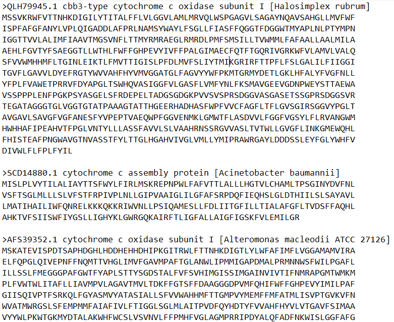

**Looks good!**  
All sequences are FASTA formatted properly. Now, they can be aligned.

## Step 4:

### Align the Sequences

Using MSA from the BiocManager package

```
# - file manipulation
# - Long Runtime
seqaln(fst, id=df$taxa_genus, exefile="msa",
       outfile="align1.fasta", protein=TRUE, seqgroup=FALSE,
       refine=FALSE, verbose=FALSE)
```

File made: “align1.fasta”  
“protein” is set to **TRUE** because I’m using amino acid sequences. If you’re using nucleotide sequences, simply set it to FALSE.

Now it’s aligned in that new fasta file.  
For model testing, we’ll need to change it from a fasta format to a phydat format.

```r
cox1 <- read.phyDat("./align1.fasta",
                    format = "fasta",
                    type = "AA")

class(cox1)
```

```
## [1] "phyDat"
```

## Step 5

### Model test for best fit

Model test to see which model best fits the data to make the most accurate phylogeny.

```r
# runtime ~ 2 hr
# - file manipulation
mod <- modelTest(cox1)

write.csv(mod,file="model_test_cox1.csv",quote=FALSE,col.names=TRUE)
```

```
# - LONG runtime ~ 2 hr
# - file manipulation
mod <- modelTest(cox1)

write.csv(mod,file="model_test_cox1.csv",quote=FALSE,col.names=TRUE)
```

File made: “model_test_cox1.csv”

```r
mod <-
  read_csv("./model_test_cox1.csv")

mod %>%
  kable() %>%
  kable_material_dark(lightable_options = 'hover') %>%
  scroll_box(width="900px", height= "350px")
```

| …1 | Model | df | logLik | AIC | AICw | AICc | AICcw | BIC |
| --- | --- | --- | --- | --- | --- | --- | --- | --- |
| 1 | WAG | 59 | -26467.11 | 53052.22 | 0.0000000 | 53059.70 | 0.000000 | 53342.19 |
| 2 | WAG+I | 60 | -26467.11 | 53054.22 | 0.0000000 | 53061.96 | 0.000000 | 53349.11 |
| 3 | WAG+G(4) | 60 | -26056.72 | 52233.43 | 0.0000000 | 52241.17 | 0.000000 | 52528.32 |
| 4 | WAG+G(4)+I | 61 | -26056.72 | 52235.43 | 0.0000000 | 52243.44 | 0.000000 | 52535.23 |
| 5 | JTT | 59 | -26784.24 | 53686.48 | 0.0000000 | 53693.96 | 0.000000 | 53976.45 |
| 6 | JTT+I | 60 | -26784.24 | 53688.48 | 0.0000000 | 53696.22 | 0.000000 | 53983.36 |
| 7 | JTT+G(4) | 60 | -26285.45 | 52690.89 | 0.0000000 | 52698.63 | 0.000000 | 52985.78 |
| 8 | JTT+G(4)+I | 61 | -26285.45 | 52692.89 | 0.0000000 | 52700.90 | 0.000000 | 52992.69 |
| 9 | LG | 59 | -26470.34 | 53058.68 | 0.0000000 | 53066.16 | 0.000000 | 53348.65 |
| 10 | LG+I | 60 | -26470.34 | 53060.68 | 0.0000000 | 53068.42 | 0.000000 | 53355.57 |
| 11 | LG+G(4) | 60 | -25953.82 | 52027.64 | 0.7310586 | 52035.38 | 0.756428 | 52322.52 |
| 12 | LG+G(4)+I | 61 | -25953.82 | 52029.64 | 0.2689414 | 52037.64 | 0.243572 | 52329.44 |
| 13 | Dayhoff | 59 | -27012.65 | 54143.30 | 0.0000000 | 54150.77 | 0.000000 | 54433.26 |
| 14 | Dayhoff+I | 60 | -27012.65 | 54145.30 | 0.0000000 | 54153.03 | 0.000000 | 54440.18 |
| 15 | Dayhoff+G(4) | 60 | -26485.73 | 53091.46 | 0.0000000 | 53099.19 | 0.000000 | 53386.34 |
| 16 | Dayhoff+G(4)+I | 61 | -26485.73 | 53093.46 | 0.0000000 | 53101.46 | 0.000000 | 53393.26 |
| 17 | cpREV | 59 | -26635.50 | 53389.00 | 0.0000000 | 53396.47 | 0.000000 | 53678.96 |
| 18 | cpREV+I | 60 | -26635.50 | 53391.00 | 0.0000000 | 53398.73 | 0.000000 | 53685.88 |
| 19 | cpREV+G(4) | 60 | -26161.84 | 52443.68 | 0.0000000 | 52451.42 | 0.000000 | 52738.56 |
| 20 | cpREV+G(4)+I | 61 | -26161.84 | 52445.68 | 0.0000000 | 52453.68 | 0.000000 | 52745.48 |
| 21 | mtmam | 59 | -28578.52 | 57275.04 | 0.0000000 | 57282.52 | 0.000000 | 57565.01 |
| 22 | mtmam+I | 60 | -28578.52 | 57277.04 | 0.0000000 | 57284.78 | 0.000000 | 57571.93 |
| 23 | mtmam+G(4) | 60 | -27391.79 | 54903.57 | 0.0000000 | 54911.31 | 0.000000 | 55198.45 |
| 24 | mtmam+G(4)+I | 61 | -27391.79 | 54905.57 | 0.0000000 | 54913.57 | 0.000000 | 55205.37 |
| 25 | mtArt | 59 | -27839.46 | 55796.92 | 0.0000000 | 55804.39 | 0.000000 | 56086.89 |
| 26 | mtArt+I | 60 | -27839.46 | 55798.92 | 0.0000000 | 55806.66 | 0.000000 | 56093.80 |
| 27 | mtArt+G(4) | 60 | -26730.53 | 53581.05 | 0.0000000 | 53588.79 | 0.000000 | 53875.94 |
| 28 | mtArt+G(4)+I | 61 | -26730.53 | 53583.05 | 0.0000000 | 53591.06 | 0.000000 | 53882.85 |
| 29 | MtZoa | 59 | -27114.11 | 54346.22 | 0.0000000 | 54353.70 | 0.000000 | 54636.19 |
| 30 | MtZoa+I | 60 | -27114.11 | 54348.22 | 0.0000000 | 54355.96 | 0.000000 | 54643.11 |
| 31 | MtZoa+G(4) | 60 | -26219.25 | 52558.50 | 0.0000000 | 52566.24 | 0.000000 | 52853.38 |
| 32 | MtZoa+G(4)+I | 61 | -26219.25 | 52560.50 | 0.0000000 | 52568.50 | 0.000000 | 52860.30 |
| 33 | mtREV24 | 59 | -27497.48 | 55112.97 | 0.0000000 | 55120.45 | 0.000000 | 55402.94 |
| 34 | mtREV24+I | 60 | -27497.48 | 55114.97 | 0.0000000 | 55122.71 | 0.000000 | 55409.85 |
| 35 | mtREV24+G(4) | 60 | -26707.19 | 53534.38 | 0.0000000 | 53542.12 | 0.000000 | 53829.26 |
| 36 | mtREV24+G(4)+I | 61 | -26707.19 | 53536.38 | 0.0000000 | 53544.38 | 0.000000 | 53836.18 |
| 37 | VT | 59 | -26704.72 | 53527.43 | 0.0000000 | 53534.91 | 0.000000 | 53817.40 |
| 38 | VT+I | 60 | -26704.72 | 53529.43 | 0.0000000 | 53537.17 | 0.000000 | 53824.32 |
| 39 | VT+G(4) | 60 | -26239.87 | 52599.75 | 0.0000000 | 52607.48 | 0.000000 | 52894.63 |
| 40 | VT+G(4)+I | 61 | -26239.87 | 52601.75 | 0.0000000 | 52609.75 | 0.000000 | 52901.55 |
| 41 | RtREV | 59 | -26737.85 | 53593.70 | 0.0000000 | 53601.17 | 0.000000 | 53883.67 |
| 42 | RtREV+I | 60 | -26737.85 | 53595.70 | 0.0000000 | 53603.43 | 0.000000 | 53890.58 |
| 43 | RtREV+G(4) | 60 | -26236.90 | 52593.80 | 0.0000000 | 52601.54 | 0.000000 | 52888.69 |
| 44 | RtREV+G(4)+I | 61 | -26236.90 | 52595.80 | 0.0000000 | 52603.81 | 0.000000 | 52895.60 |
| 45 | HIVw | 59 | -28955.93 | 58029.87 | 0.0000000 | 58037.35 | 0.000000 | 58319.84 |
| 46 | HIVw+I | 60 | -28955.93 | 58031.87 | 0.0000000 | 58039.61 | 0.000000 | 58326.75 |
| 47 | HIVw+G(4) | 60 | -28195.32 | 56510.65 | 0.0000000 | 56518.39 | 0.000000 | 56805.53 |
| 48 | HIVw+G(4)+I | 61 | -28195.32 | 56512.65 | 0.0000000 | 56520.65 | 0.000000 | 56812.45 |
| 49 | HIVb | 59 | -27786.09 | 55690.18 | 0.0000000 | 55697.66 | 0.000000 | 55980.15 |
| 50 | HIVb+I | 60 | -27786.09 | 55692.18 | 0.0000000 | 55699.92 | 0.000000 | 55987.06 |
| 51 | HIVb+G(4) | 60 | -27073.49 | 54266.97 | 0.0000000 | 54274.71 | 0.000000 | 54561.86 |
| 52 | HIVb+G(4)+I | 61 | -27073.49 | 54268.97 | 0.0000000 | 54276.98 | 0.000000 | 54568.77 |
| 53 | FLU | 59 | -27360.01 | 54838.01 | 0.0000000 | 54845.49 | 0.000000 | 55127.98 |
| 54 | FLU+I | 60 | -27360.01 | 54840.01 | 0.0000000 | 54847.75 | 0.000000 | 55134.90 |
| 55 | FLU+G(4) | 60 | -26782.62 | 53685.24 | 0.0000000 | 53692.97 | 0.000000 | 53980.12 |
| 56 | FLU+G(4)+I | 61 | -26782.62 | 53687.24 | 0.0000000 | 53695.24 | 0.000000 | 53987.03 |
| 57 | Blosum62 | 59 | -26350.17 | 52818.35 | 0.0000000 | 52825.82 | 0.000000 | 53108.31 |
| 58 | Blosum62+I | 60 | -26350.17 | 52820.35 | 0.0000000 | 52828.08 | 0.000000 | 53115.23 |
| 59 | Blosum62+G(4) | 60 | -25994.73 | 52109.45 | 0.0000000 | 52117.19 | 0.000000 | 52404.34 |
| 60 | Blosum62+G(4)+I | 61 | -25994.73 | 52111.45 | 0.0000000 | 52119.46 | 0.000000 | 52411.25 |
| 61 | Dayhoff_DCMut | 59 | -27008.11 | 54134.22 | 0.0000000 | 54141.70 | 0.000000 | 54424.19 |
| 62 | Dayhoff_DCMut+I | 60 | -27008.11 | 54136.22 | 0.0000000 | 54143.96 | 0.000000 | 54431.10 |
| 63 | Dayhoff_DCMut+G(4) | 60 | -26483.68 | 53087.37 | 0.0000000 | 53095.11 | 0.000000 | 53382.25 |
| 64 | Dayhoff_DCMut+G(4)+I | 61 | -26483.68 | 53089.37 | 0.0000000 | 53097.37 | 0.000000 | 53389.17 |
| 65 | JTT_DCMut | 59 | -26780.86 | 53679.72 | 0.0000000 | 53687.19 | 0.000000 | 53969.68 |
| 66 | JTT_DCMut+I | 60 | -26780.86 | 53681.72 | 0.0000000 | 53689.45 | 0.000000 | 53976.60 |
| 67 | JTT_DCMut+G(4) | 60 | -26285.50 | 52690.99 | 0.0000000 | 52698.73 | 0.000000 | 52985.88 |
| 68 | JTT_DCMut+G(4)+I | 61 | -26285.50 | 52692.99 | 0.0000000 | 52701.00 | 0.000000 | 52992.79 |

### Picking a model

I want the model that has the best value for both BIC and AIC overall. It’s best to look at both values side-by-side like in the table, but I chose to check minimum average of BIC and AIC.

```r
mod$fit <- ((mod$BIC+mod$AIC)/2)

#Show best model based on min value of that new column
c(as.character(mod[mod$fit == min(mod$fit),2]),as.character(min(mod$fit)))
```

```
## [1] "LG+G(4)"          "52175.0793189994"
```

#### Best model: LG+G(4) with a value of “52175”

## Step 7

### Make the ML tree(s)

Alright, let’s take inventory: -Model: LG+G(4)  
-Alignment: Done.

So I’ve got a file, and I have a model to make a phylogeny with, so its time to grow a tree.

I’m using pml_bb from the **phangorn** package.

```
# - Runtime ~ 1 hr 15min
# - file manipulation
fitLG <- pml_bb(cox1, model="LG+G(4)")

saveRDS(fitLG, file="fitlg.rds")
```

File created: “fitlg.rds”

First Maximum Likelihood tree built!

Let’s talk bootstrapping. The default option for phangorn is “[UltraFast bootstrapping](https://academic.oup.com/mbe/article/30/5/1188/997508)” (Minh, Nguyen, and Haeseler 2013). Reading into it, it’s a reliable method here. However, in class we talk only about standard bootstrapping. For the sake of ease of access, I’m also including the steps for standard bootstrapping here, and comparing the two next to each other:

Setting up standard bootstrapping:

```
- Long runtime ~ 1 hr
- file manipulation

fitLG <-
  read_rds("fitlg.rds")

bs <- bootstrap.pml(fitLG, bs=100, optNni=TRUE,
                     control = pml.control(trace = 0))

saveRDS(bs, file="bs.rds")
```

Alright, both are made, and ready to plot!

## Step 8

### Plotting the Trees

Ultrafast BS vs Standard BS to compare:  
First step is always: Root your tree  
Here, our outgroup is Archaea

Root:

```
bs <-
  read_rds("bs.rds")

root <-
  root(fitLG$tree,outgroup="Archaea",resolve.root=TRUE)
```

#### Plot:

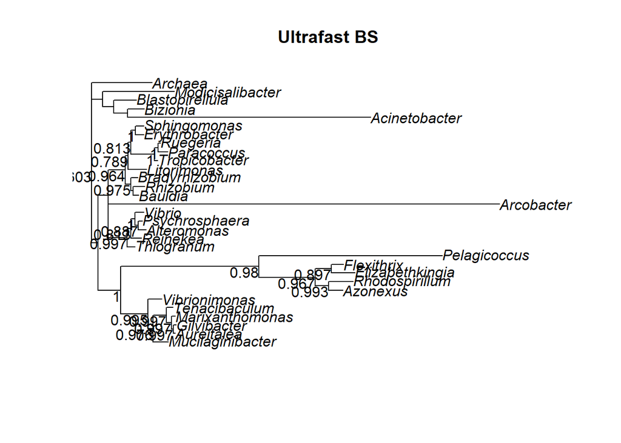

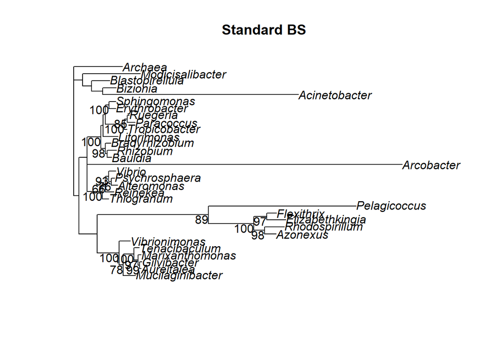

```
#Ultrafast Bootstrapping
ufbsplot<-
  plotBS(root, p = .5, type="p", digits=2, main="Ultrafast BS")

#Assign standard bs values
stdbs_tree <- plotBS(fitLG$tree, bs, type = "n")

#Standard Bootstrapping
stdbsplot <-
  plotBS(root, bs, p = 50, type="p", main="Standard BS")
```

Well, it’s UGLY. But let’s save it to a newick format so we can play around with it in a tree viewer

Convert from Phy to Newick format

```
- file manipulation
Now from phy to tree: (newick format)
write.tree(fitLG$tree, "cox1_ufsb_nwk.tree")

write.tree(stdbs_tree, "cox1_stdbs_nwk.tree")
```

## Step 9

### Tree Viewing

So we have a tree. I’m using ggtree to view the tree and make it look less of a mess.

Read in the newick trees:

```
uf <-
  read.tree("cox1_ufsb_nwk.tree")

std <-
  read.tree("cox1_stdbs_nwk.tree")
```

Root the tree

```
rootuf <-
  root(uf,outgroup="Archaea",resolve.root=TRUE)
```

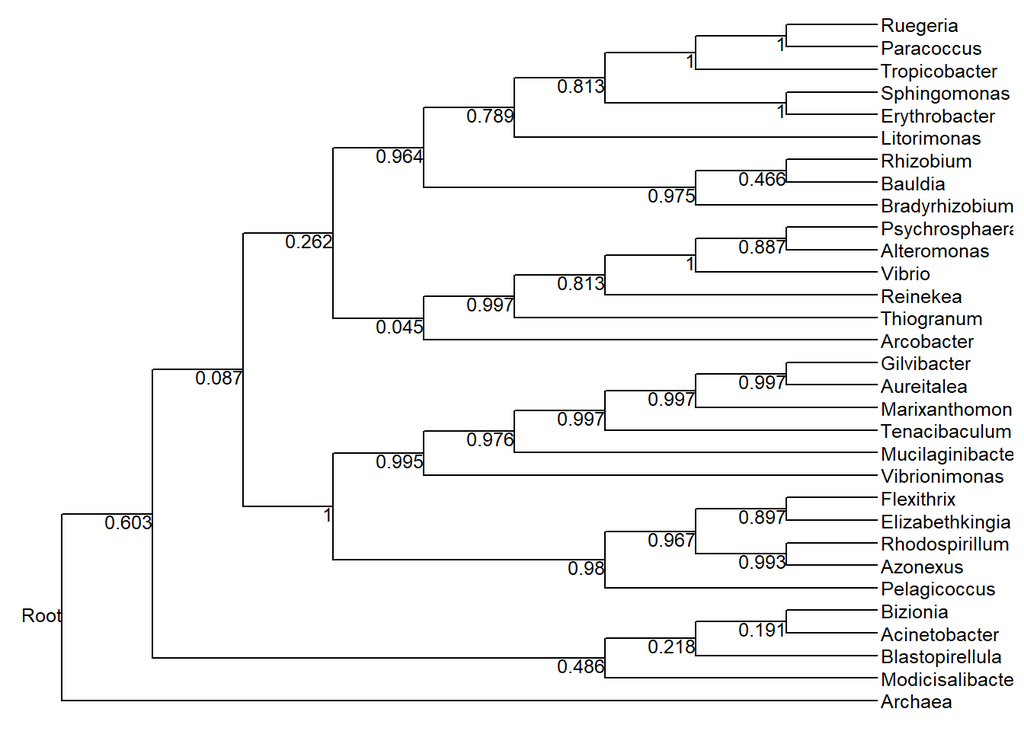

```r
ggtree(rootuf, layout="rectangular", branch.length = "none")+
  geom_tiplab(size=3.3)+
  ggplot2::xlim(0, 10)+
  geom_text2(aes(subset = !isTip, label=label),
             hjust=1,
             vjust=1,
             size=3.3)
```

**Looks GREAT!!!**

## Step 10

### Save Your Tree

simply using ggsave() saves the tree you most recently created as a .png.

```
# - File manipulation
ggsave("uf_ml_tree.png")
```

References: Minh, Bui Quang, Minh Anh Thi Nguyen, and Arndt von Haeseler. 2013. “Ultrafast Approximation for Phylogenetic Bootstrap.” Molecular Biology and Evolution 30 (5): 1188–95.